# Stat 11 Week 6 & 8

Random Variables and Probability Rules - Part 1

Prof. Suzy Thornton

# 1. Random Phenomena

Random variables result in random events. Each random variable has a sample space of outcome events. A trials results in an observed event.

## Example: Rolling a six-sided die

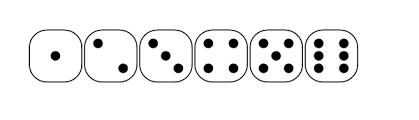

- The random event is the face of the die that lands upward.
- The sample space of outcomes is this six faces of the die.
- A trial represents the act of physically rolling a six-sided die and producing an observation of this random phenomena.

## Example: Flipping an unfair coin

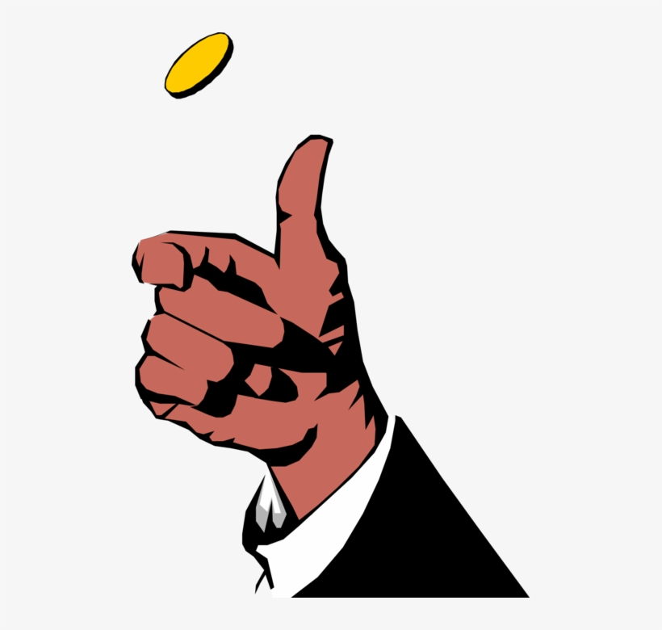

- What is the random event?
- What is the sample space of outcomes?
- A trial represents the act of physically flipping the coin and producing an observation of this random phenomena.

# 2. Law of Large Numbers

As we repeat a random process over and over again, the proportion of times that an event occurs eventually settles down to a single probability that describes the relative frequency with which this event occurs. In short, the Law of Large Numbers (LLN) asserts that relative frequencies settle down to a single value in the long run.

Empirical probability - uses the laws of probability to describe the long-run behavior of repeated observations of a random event.

## Example: Rolling a six-sided die

```r
# Consider a six sided die
S = c(1,2,3,4,5,6)

# Roll the die once
sample(S, size=1, replace=TRUE)
```

```
## [1] 6
```

Q) What’s the probability that the die lands on a “six”?

1. $1/6=$ 0.1666667

Q) What’s the probability that we roll the dice again and it lands on a “six” again?<>

**Note:** There is no such thing as a “law of averages”. This is also known as “the gambler’s fallacy”.

```r
# Roll the die 10000 times
trials = 10000
observations = sample(S, size=trials, replace=TRUE)
observations
```

[output not shown]

[output cut: 263 more lines]

Q) How frequently did the die land on a “six”?

1. 0.1616

FYI you can find this probability with the R code:

```r
sum(obbservations == 6)/trials
```

## Example: Flipping an unfair coin

Q) How could we figure out the probability that our unfair coin lands on a “heads”?

**Note:** There is another way to use the laws of probability. For example, perhaps I’m a magician and I’m flipping a coin and you don’t know whether or not the coin is fair. You could express your doubts with a subjective probability.

Subjective probability - uses the laws of probability to describe a personal degree of (un)certainty, unrelated to any kind of long-run behavior.

# 3. Laws of Probability

## 1) A probability is a number between 0 and 1.

$$0 \leq Pr(A) \leq 1, \quad\text{for $A
\in S$}$$

## 2) The probability of the set of all possible outcomes of a trial is 1.

$$Pr(S)=1$$

## 3) The probability of an event not occuring is equal to 1 minus the probability the event does occur.

$$Pr(A^{C}) = 1 - Pr(A)$$

## 4) If an event $A$ is disjoint from another event $B$, then the probability that one event or the other event occurs is the sum of their two individual probabilities.

$$Pr(A\text{ or }B) = Pr(A) + Pr(B),
\quad\text{when }Pr(A\text{ and }B) = 0$$

## 5) If an event $A$ is independent of another event $B$, then the probability that both events occur is the product of the probabilities of the two individual events.

$$Pr(A\text{ and } B) = Pr(A)\times Pr(B),
\quad\text{when $A$ and $B$ are independent events}$$

## Example: Selecting colored balls from a box

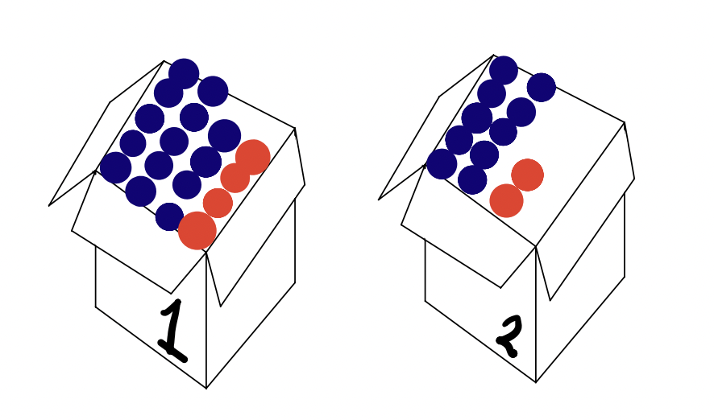

*Two boxes contain red and blue balls. Box 1 has 14 blue balls and 4 red balls. Box 2 has 10 blue balls and 2 red balls.*

The random phenomena we are considering is drawing a single ball from each of the two boxes without looking.

- What is the sample space for this random phenomena?
- Are you more likely to choose a blue ball from Box 1 or Box 2?
- What is the probability that you select a blue ball from Box 1 and a blue ball from Box 2